# Exploring and Visualizing the Iris Dataset in R

Karen Kindaro

October 10, 2026

# 1 Introduction

This code-through explains how to explore and change a dataset in R. I use the `iris` dataset because it is already included in R, so no file needs to be downloaded. The dataset contains measurements for 150 flowers from three iris species: setosa, versicolor, and virginica.

By the end of this tutorial, you will know how to:

- view a dataset;
- select and filter observations;
- create a new variable;
- summarize information by group; and
- create a graph with `ggplot2`.

# 2 Load and Preview the Data

First, I copy the built-in dataset into an object called `flowers`. The `head()` function prints the first six rows. This is a quick way to understand what the data looks like.

```r
flowers <- iris
head(flowers)
```

```
##   Sepal.Length Sepal.Width Petal.Length Petal.Width Species
## 1          5.1         3.5          1.4         0.2  setosa
## 2          4.9         3.0          1.4         0.2  setosa
## 3          4.7         3.2          1.3         0.2  setosa
## 4          4.6         3.1          1.5         0.2  setosa
## 5          5.0         3.6          1.4         0.2  setosa
## 6          5.4         3.9          1.7         0.4  setosa
```

Each row represents one flower. The first four columns contain measurements in centimeters, and `Species` gives the flower’s species.

# 3 Check the Dataset Structure

The `glimpse()` function shows the number of rows and columns, the type of each variable, and a few values. The `count()` function shows how many flowers belong to each species.

```r
glimpse(flowers)
```

```
## Rows: 150
## Columns: 5
## $ Sepal.Length <dbl> 5.1, 4.9, 4.7, 4.6, 5.0, 5.4, 4.6, 5.0, 4.4, 4.9, 5.4, 4.…
## $ Sepal.Width  <dbl> 3.5, 3.0, 3.2, 3.1, 3.6, 3.9, 3.4, 3.4, 2.9, 3.1, 3.7, 3.…
## $ Petal.Length <dbl> 1.4, 1.4, 1.3, 1.5, 1.4, 1.7, 1.4, 1.5, 1.4, 1.5, 1.5, 1.…
## $ Petal.Width  <dbl> 0.2, 0.2, 0.2, 0.2, 0.2, 0.4, 0.3, 0.2, 0.2, 0.1, 0.2, 0.…
## $ Species      <fct> setosa, setosa, setosa, setosa, setosa, setosa, setosa, s…
```

```r
flowers %>%
  count(Species)
```

```
##      Species  n
## 1     setosa 50
## 2 versicolor 50
## 3  virginica 50
```

The dataset has 150 rows and 5 columns. It has 50 flowers from each species, so the three groups are the same size.

# 4 Select and Filter Rows

Sometimes we only need a small part of a dataset. In the next step, I use `filter()` to keep only setosa flowers. I use `select()` to keep three useful columns, and `slice_head()` to print only the first six rows.

```r
setosa_sample <- flowers %>%
  filter(Species == "setosa") %>%
  select(Sepal.Length, Petal.Length, Species) %>%
  slice_head(n = 6)

setosa_sample
```

```
##   Sepal.Length Petal.Length Species
## 1          5.1          1.4  setosa
## 2          4.9          1.4  setosa
## 3          4.7          1.3  setosa
## 4          4.6          1.5  setosa
## 5          5.0          1.4  setosa
## 6          5.4          1.7  setosa
```

The new object is smaller than the original dataset. It contains only setosa flowers and only the columns selected in the code.

# 5 Create a New Variable

The `mutate()` function creates or changes a variable. Here, I create `Petal.Ratio` by dividing petal length by petal width. The `round()` function makes the result easier to read.

```r
flowers_changed <- flowers %>%
  mutate(Petal.Ratio = round(Petal.Length / Petal.Width, 2))

flowers_changed %>%
  select(Petal.Length, Petal.Width, Petal.Ratio, Species) %>%
  slice_head(n = 6)
```

```
##   Petal.Length Petal.Width Petal.Ratio Species
## 1          1.4         0.2        7.00  setosa
## 2          1.4         0.2        7.00  setosa
## 3          1.3         0.2        6.50  setosa
## 4          1.5         0.2        7.50  setosa
## 5          1.4         0.2        7.00  setosa
## 6          1.7         0.4        4.25  setosa
```

The original dataset had five columns. The changed dataset has a sixth column, `Petal.Ratio`, while the original measurements remain unchanged.

# 6 Summarize the Species

The `group_by()` and `summarise()` functions work together. First, the flowers are placed into species groups. Then R calculates the number of flowers and the average sepal and petal lengths for every group.

```r
species_summary <- flowers %>%
  group_by(Species) %>%
  summarise(
    Number_of_Flowers = n(),
    Average_Sepal_Length = round(mean(Sepal.Length), 2),
    Average_Petal_Length = round(mean(Petal.Length), 2)
  )

kable(
  species_summary,
  caption = "Average Flower Measurements by Species",
  align = "c"
)
```

Average Flower Measurements by Species

| Species | Number_of_Flowers | Average_Sepal_Length | Average_Petal_Length |
| --- | --- | --- | --- |
| setosa | 50 | 5.01 | 1.46 |
| versicolor | 50 | 5.94 | 4.26 |
| virginica | 50 | 6.59 | 5.55 |

The table shows that setosa has the shortest average petals, while virginica has the longest average petals.

# 7 Make a Graph

A graph can make group differences easier to see. The following scatterplot compares sepal length with petal length. Color represents species, and `geom_smooth()` adds one trend line for each group.

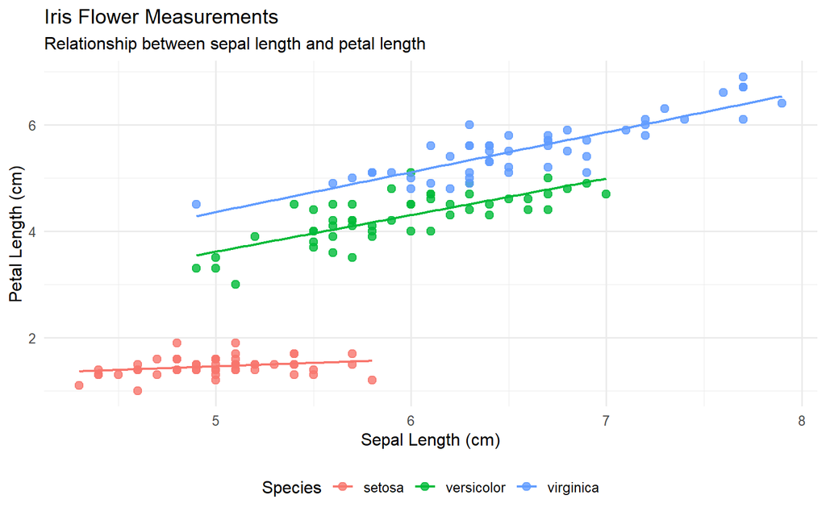

Sepal Length and Petal Length by Iris Species

```r
ggplot(flowers, aes(x = Sepal.Length, y = Petal.Length, color = Species)) +
  geom_point(size = 2.5, alpha = 0.8) +
  geom_smooth(method = "lm", se = FALSE, linewidth = 0.8) +
  labs(
    title = "Iris Flower Measurements",
    subtitle = "Relationship between sepal length and petal length",
    x = "Sepal Length (cm)",
    y = "Petal Length (cm)",
    color = "Species"
  ) +
  theme_minimal(base_size = 12) +
  theme(legend.position = "bottom")
```

The colors form three visible groups. Setosa flowers have much shorter petals. Virginica flowers generally have the longest petals and sepals. The upward trend lines also show that flowers with longer sepals usually have longer petals.

# 8 Conclusion

In this tutorial, I used a built-in dataset to demonstrate a simple data analysis process. I previewed the data, checked its structure, filtered rows, selected columns, created a new variable, calculated group summaries, and made a graph. These same steps can be used with many other datasets in R.